# Creating and Improving Visualizations with NHANES Data

Assignment Week 3

G Crawford-Gee

2026-10-04

# Exercise 1: Reproducing and arranging ggplot2 figures

## Individual Figures

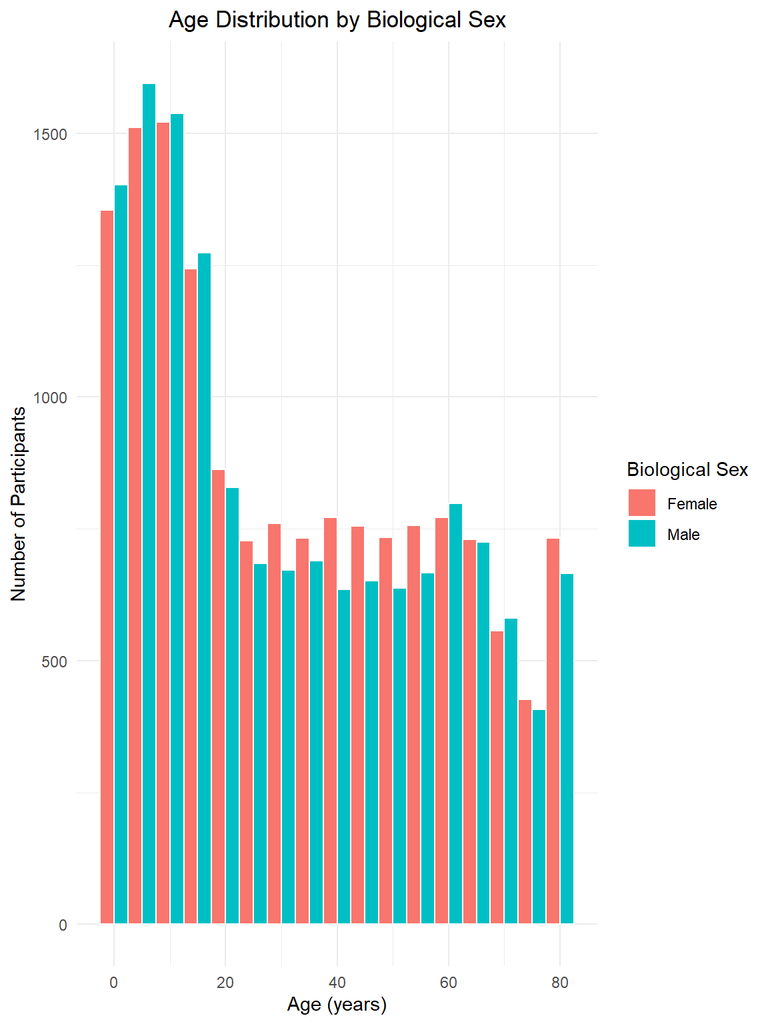

```r
# Figure 1: Vertical bar chart of age
# Each bin represents exactly 5 years.
plot1 <- ggplot(
  cleaned_NHANES,
  aes(x = age, fill = gender)
) +
  geom_histogram(
    binwidth = 5,
    boundary = 17.5,
    position = "dodge",
    colour = "white"
  ) +
  labs(
    title = "Age Distribution by Biological Sex",
    x = "Age (years)",
    y = "Number of Participants",
    fill = "Biological Sex"
  ) +
  theme_minimal() +
  theme(
    plot.title = element_text(hjust = 0.5)
  )


# Figure 2: Vertical stacked bar chart
# Each ethnicity bar is stacked according to biological sex.
plot2 <- ggplot(
  cleaned_NHANES,
  aes(
    x = ethnicity_2,
    fill = gender
  )
) +
  geom_bar(
    position = "fill",
    width = 0.95
  ) +
  labs(
    title = "Biological Sex Distribution Within Race/Ethnicity",
    x = "Race/Ethnicity",
    y = "Proportion",
    fill = "Biological Sex"
  ) +
  theme_minimal() +
  theme(
    plot.title = element_text(hjust = 0.5),
    axis.text.x = element_text(
      angle = 45,
      hjust = 1
    )
  )

# Display the individual plots
plot1
```

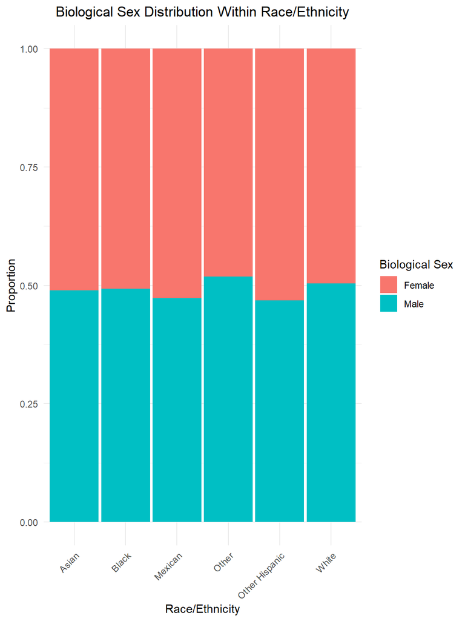

```r
plot2
```

## Combined Figures

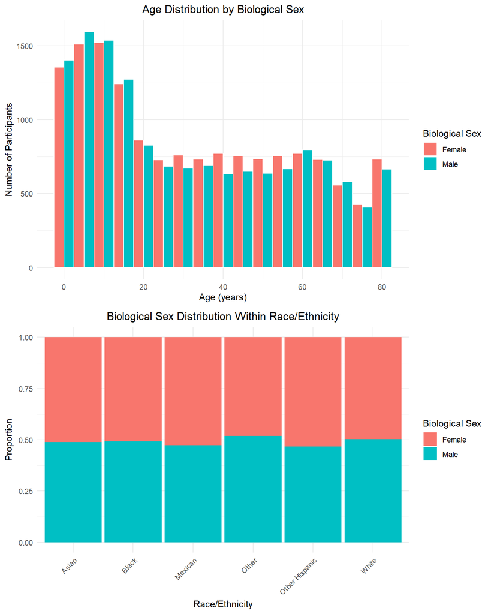

```r
# Combine the two plots using cowplot
combined_cowplot <- plot_grid(
  plot1,
  plot2,
  ncol = 1,
  align = "v"
)

# Display the combined cowplot figure
combined_cowplot
```

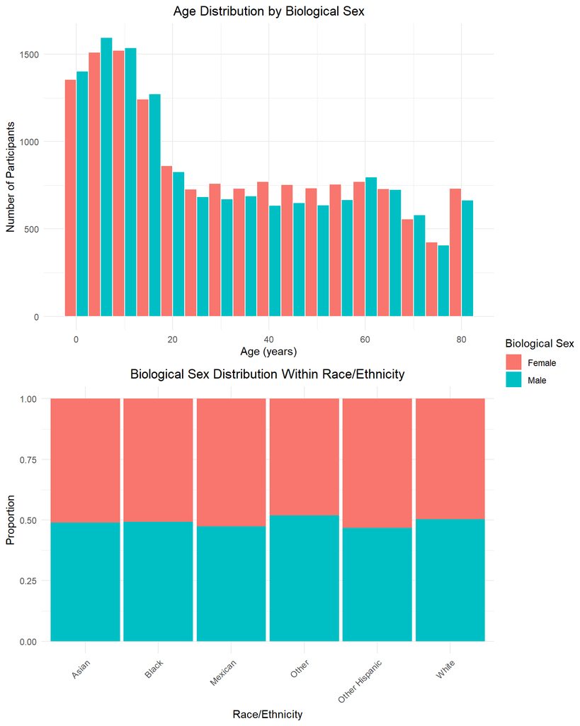

```r
# Combine the same plots using ggpubr
combined_ggpubr <- ggarrange(
  plot1,
  plot2,
  ncol = 1,
  nrow = 2,
  common.legend = TRUE,
  legend = "right"
)

# Display the combined ggpubr figure
combined_ggpubr
```

### Layout Comparison

Both `plot_grid()` from the cowplot package and `ggarrange()` from the ggpubr package can be used to combine multiple ggplot2 figures into one output. With this specific data, the overall arrangement would be similar because both functions place the figures into single vertical columns.

However, `ggarrange()` creates a common legend, which avoids unnecessarily repeating the biological-sex legend. For these plots, I prefer the `ggarrange()` layout because the shared legend creates a cleaner and less cluttered presentation while keeping the two figures aligned. This allows the two figures to be compared directly without having to move between separate pages.

# Exercise 2: Visualizing key characteristics

```r
DT::datatable(
  cleaned_NHANES,
  options = list(
    pageLength = 10,
    scrollX = TRUE
  )
)
```

|  | ...1 | patient_id | bp_comment | systolic_bp_1 | diastolic_bp_1 | systolic_bp_2 | diastolic_bp_2 | systolic_bp_3 | diastolic_bp_3 | systolic_bp_4 | diastolic_bp_4 | wave_id | gender | age | ethnicity_1 | ethnicity_2 | education | marital_status | family_size | family_income | age_cat |
| --- | --- | --- | --- | --- | --- | --- | --- | --- | --- | --- | --- | --- | --- | --- | --- | --- | --- | --- | --- | --- | --- |
| 1 | 1 | 73557 |  | 122 | 72 | 114 | 76 | 102 | 74 |  |  | 2015 | Male | 69 | Black | Black | High School | Separated | 3 | $15,000 - $19,999 | 60+ |
| 2 | 2 | 73558 |  | 156 | 62 | 160 | 80 | 156 | 42 |  |  | 2015 | Male | 54 | White | White | High School | Married | 4 | $35,000 - $44,999 | 40-59 |
| 3 | 3 | 73559 |  | 140 | 90 | 140 | 76 | 146 | 80 |  |  | 2015 | Male | 72 | White | White | Some college | Married | 2 | $65,000 - $74,999 | 60+ |
| 4 | 4 | 73560 |  | 108 | 38 | 102 | 34 | 104 | 38 |  |  | 2015 | Male | 9 | White | White |  |  | 4 | $55,000 - $64,999 | 0-17 |
| 5 | 5 | 73561 |  | 136 | 86 | 134 | 88 | 142 | 86 |  |  | 2015 | Female | 73 | White | White | College graduate | Married | 2 | $100,000 or more | 60+ |
| 6 | 6 | 73562 |  | 160 | 84 | 158 | 82 | 154 | 80 |  |  | 2015 | Male | 56 | Mexican | Mexican | Some college | Divorced | 1 | $55,000 - $64,999 | 40-59 |
| 7 | 7 | 73563 |  |  |  |  |  |  |  |  |  | 2015 | Male | 0 | White | White |  |  | 3 | $100,000 or more | 0-17 |
| 8 | 8 | 73564 |  | 118 | 80 | 124 | 80 | 126 | 82 |  |  | 2015 | Female | 61 | White | White | College graduate | Widowed | 1 | $65,000 - $74,999 | 60+ |
| 9 | 9 | 73566 |  | 128 | 74 | 124 | 72 | 114 | 72 |  |  | 2015 | Female | 56 | White | White | High School | Divorced | 7 or more | $15,000 - $19,999 | 40-59 |
| 10 | 10 | 73567 |  | 140 | 78 | 142 | 78 | 142 | 76 |  |  | 2015 | Male | 65 | White | White | 9-11th grade | Widowed | 1 | $10,000 - $14,999 | 60+ |

[output cut: 29390 more lines]

```
## # A tibble: 1 × 4
##   missing_age missing_sex missing_eth1 missing_eth2
##         <int>       <int>        <int>        <int>
## 1           0           0            0            0
```

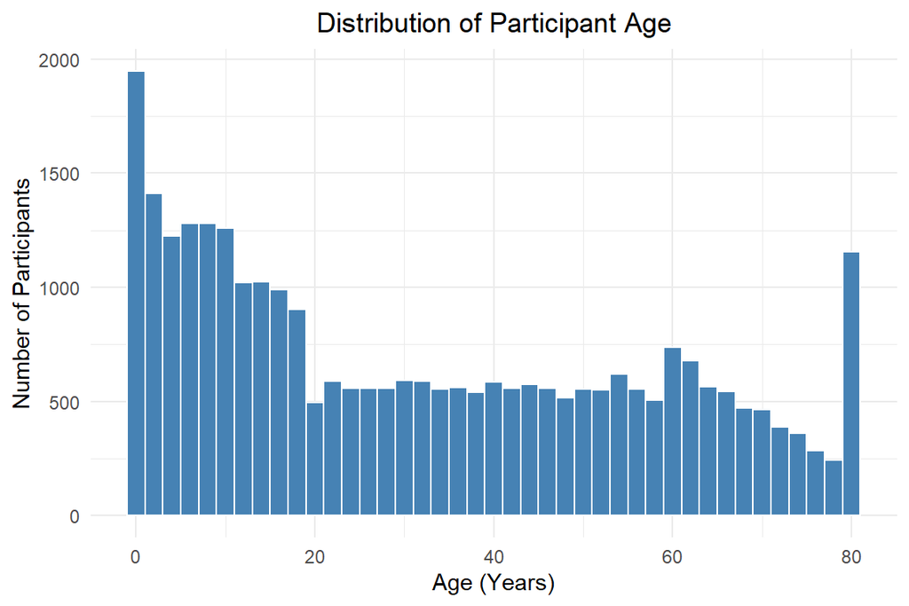

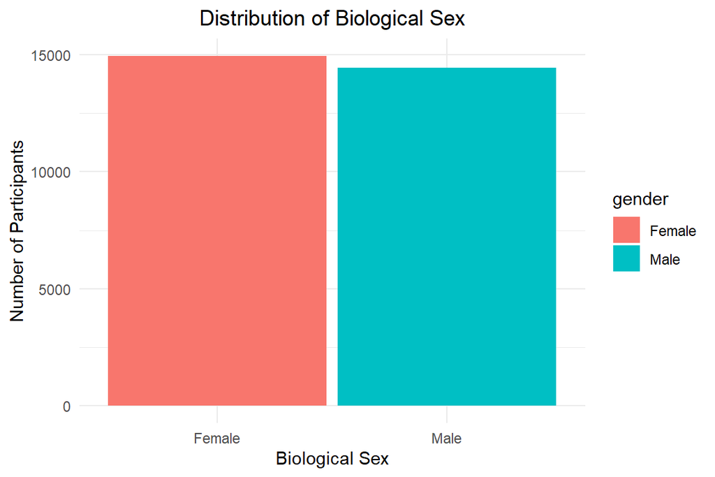

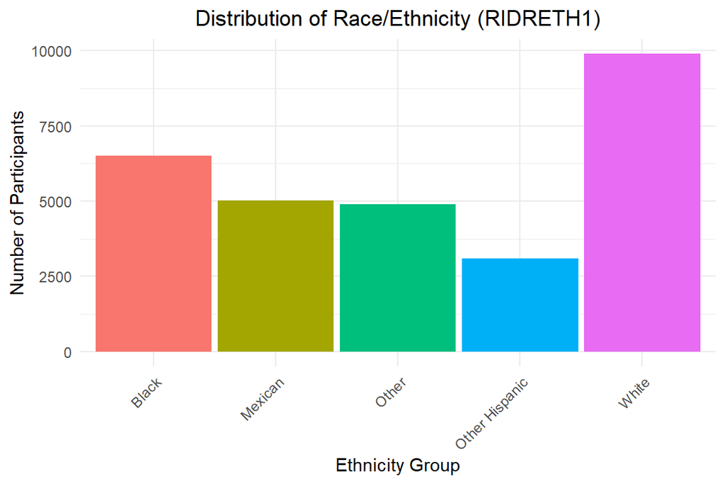

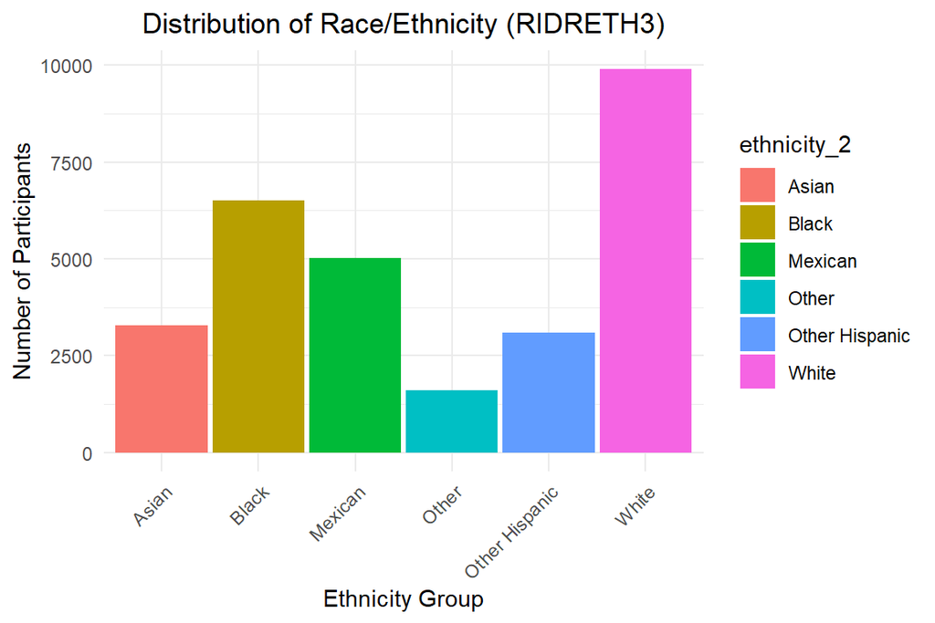

```r
## Create an output directory for saved plots
if (!dir.exists("plots")) {
  dir.create("plots")
}

## Age distribution
plot_age <- ggplot(
  cleaned_NHANES,
  aes(x = age)
) +
  geom_histogram(
    binwidth = 2,
    fill = "steelblue",
    colour = "white"
  ) +
  labs(
    title = "Distribution of Participant Age",
    x = "Age (Years)",
    y = "Number of Participants"
  ) +
   theme_minimal() +
  theme(
    plot.title = element_text(hjust = 0.5)
  )

## Biological sex distribution
plot_sex <- ggplot(
  cleaned_NHANES,
  aes(x = gender, fill = gender)
) +
  geom_bar(width = 0.95) +
  labs(
    title = "Distribution of Biological Sex",
    x = "Biological Sex",
    y = "Number of Participants"
  ) +
   theme_minimal() +
  theme(
    plot.title = element_text(hjust = 0.5)
  )

##  First ethnicity variable
plot_eth1 <- ggplot(
  cleaned_NHANES,
  aes(x = ethnicity_1, fill = ethnicity_1)
) +
  geom_bar(width = 0.95) +
  labs(
    title = "Distribution of Race/Ethnicity (RIDRETH1)",
    x = "Ethnicity Group",
    y = "Number of Participants"
  ) +
  theme_minimal() +
  theme(
    plot.title = element_text(hjust = 0.5),
    axis.text.x = element_text(
      angle = 45,
      hjust = 1
    ),
    legend.position = "none"
  )

##  Second ethnicity variable
plot_eth2 <- ggplot(
  cleaned_NHANES,
  aes(x = ethnicity_2, fill = ethnicity_2)
) +
  geom_bar(width = 0.95) +
  labs(
    title = "Distribution of Race/Ethnicity (RIDRETH3)",
    x = "Ethnicity Group",
    y = "Number of Participants"
  ) +
theme_minimal() +
  theme(
    plot.title = element_text(hjust = 0.5),
    axis.text.x = element_text(
      angle = 45,
      hjust = 1
    )
  )

##  Display plots
plot_age
plot_sex
plot_eth1
plot_eth2

##  Save plots
ggsave(
  "plots/plot_age.png",
  plot = plot_age,
  width = 6,
  height = 4
)

ggsave(
  "plots/plot_sex.png",
  plot = plot_sex,
  width = 6,
  height = 4
)

ggsave(
  "plots/plot_eth1.png",
  plot = plot_eth1,
  width = 7,
  height = 5
)

ggsave(
  "plots/plot_eth2.png",
  plot = plot_eth2,
  width = 7,
  height = 5
)

##  Calculate missing values (remember will not work if removed ethnicity)
missing_report <- cleaned_NHANES |>
  summarise(
    missing_age = sum(is.na(age)),
    missing_sex = sum(is.na(gender)),
    missing_eth1 = sum(is.na(ethnicity_1)),
    missing_eth2 = sum(is.na(ethnicity_2))
  )

missing_report
```

## Descriptive Summaries & Distribution Analysis

Note: The original NHANES demographic variables were renamed during data cleaning to descriptive names, including gender, ethnicity_1, and ethnicity_2.

### Gender

The sample is relatively evenly divided between males and females. There are 0 missing gender values.

### Ethnicity

RIDRETH3 provides more detailed race/ethnicity categories than the older RIDRETH1 classification. For example, RIDRETH3 includes a separate category for Non-Hispanic Asian participants, allowing for more specific reporting of race/ethnicity groups.

Ethnicity 1

Ethnicity 1: The RIDRETH1 distribution is dominated by the White category, followed by Black and Mexican American participants. The remaining categories represent smaller portions of the sample. There are 0 missing values.

Ethnicity 2

Ethnicity 2: The RIDRETH3 distribution is also dominated by the White category, while the classification provides additional detail by separating Non-Hispanic Asian participants into their own category. There are 0 missing values.

### Variable Decision & Discarding

Because RIDRETH3 provides more detailed race/ethnicity information, ethnicity_2 (RIDRETH3) was retained for the analysis. The older ethnicity_1 (RIDRETH1) variable was removed to avoid keeping two variables that provide similar demographic information.

```r
# Remove ethnicity_1 after comparing the two ethnicity variables:
cleaned_NHANES <- cleaned_NHANES |> select(-ethnicity_1)
```

# Exercise 3: Improving a ggplot Figure

## Suggested Improvements for Colleague’s figure.

Y-axis and Baseline Comparison

The most important issue is that the graph displays participants’ absolute body weights over time, whereas the main objective is to show how each participant’s weight has changed compared with their baseline weight at week 0. I would plot weight change relative to week 0 (in kg), with a horizontal zero line. This would make weight loss and weight gain easier to identify and compare between participants.

Clarity and Readability

The many overlapping lines and similar colours make individual trends difficult to follow. I would use a colour-blind-friendly palette, clearer line styles and a simplified legend. Alternatively, separate panels for each participant could reduce visual clutter.

Labels and Formatting

The figure lacks a descriptive title and units for body weight. I would add a more descriptive title, label the y-axis “Weight Change (kg) from Baseline” and “study duration (weeks) on the x-axis. I would also ensure all participant IDs are correctly represented in the legend or subtitle.

This would help readers interpret the study results while accounting for differences between participants. Since no control group is shown, I would also avoid concluding that the diet alone caused the observed changes.

```r
# Check the structure of the diet dataset
names(diet)
```

```
## [1] "Week"        "Participant" "Weight"
```

```r
glimpse(diet)
```

```
## Rows: 340
## Columns: 3
## $ Week        <dbl> 0, 1, 2, 3, 4, 5, 6, 7, 8, 9, 10, 11, 12, 13, 14, 15, 16, …
## $ Participant <dbl> 1, 1, 1, 1, 1, 1, 1, 1, 1, 1, 1, 1, 1, 1, 1, 1, 1, 2, 2, 2…
## $ Weight      <dbl> 95.94829, 94.15635, 93.63969, 93.05969, 91.18335, 89.95467…
```

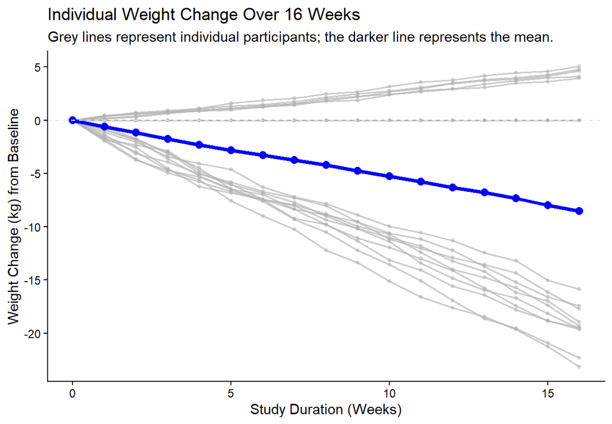

```r
# Calculate each participant's baseline weight
# and change in weight from baseline.
diet_cleaned <- diet |>
  group_by(Participant) |>
  mutate(
    baseline_weight = Weight[Week == 0][1],
    weight_change = Weight - baseline_weight
  ) |>
  ungroup()


# Create the improved visualization
overhauled_plot <- ggplot(
  diet_cleaned,
  aes(
    x = Week,
    y = weight_change
  )
) +

  # Show individual participant trajectories
  geom_line(
  aes(group = Participant),
  colour = "grey70",
  alpha = 0.7,
  linewidth = 0.6
) +

  # Show individual observations
  geom_point(
    colour = "grey70",
    alpha = 0.5,
    size = 1
  ) +

  # Add the mean weight change across participants
  stat_summary(
    fun = mean,
    geom = "line",
    colour = "blue",
    linewidth = 1.3
  ) +

  stat_summary(
    fun = mean,
    geom = "point",
    colour = "blue",
    size = 2.5
  ) +

  # Add a zero reference line
  geom_hline(
    yintercept = 0,
    linetype = "dashed",
    colour = "azure2"
  ) +

  labs(
    title = "Individual Weight Change Over 16 Weeks",
    subtitle = "Grey lines represent individual participants; the darker line represents the mean.",
    x = "Study Duration (Weeks)",
    y = "Weight Change (kg) from Baseline"
  ) +

  theme_classic()

# Display the improved visualization in the PDF
overhauled_plot
```

# Exercise 4: Exploring Relationships Through Visualizations

```r
# four SBP
sbp_cols <- c(
  "systolic_bp_1",
  "systolic_bp_2",
  "systolic_bp_3",
  "systolic_bp_4"
)

# average SBP
cleaned_NHANES <- cleaned_NHANES |>
  mutate(
    avg_sbp = rowMeans(
      cbind(
        systolic_bp_1,
        systolic_bp_2,
        systolic_bp_3,
        systolic_bp_4
      ),
      na.rm = TRUE
    ),
    avg_sbp = if_else(is.nan(avg_sbp), NA_real_, avg_sbp)
  )

# original sample size
initial_n <- nrow(cleaned_NHANES)

# Create Final Analytical Sample
initial_n <- nrow(cleaned_NHANES)
final_sample <- cleaned_NHANES |>
  filter(
    !is.na(age),
    !is.na(gender),
    !is.na(avg_sbp)
  )

final_n <- nrow(final_sample)
dropped_n <- initial_n - final_n

### Display Sample Sizes
sample_sizes <- tibble(
  initial_sample = initial_n,
  final_sample = final_n,
  excluded = dropped_n
)

sample_sizes
```

```
## # A tibble: 1 × 3
##   initial_sample final_sample excluded
##            <int>        <int>    <int>
## 1          29400        21604     7796
```

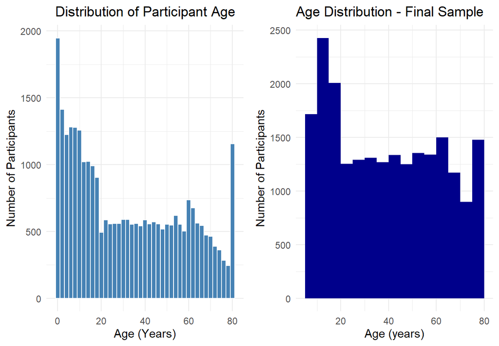

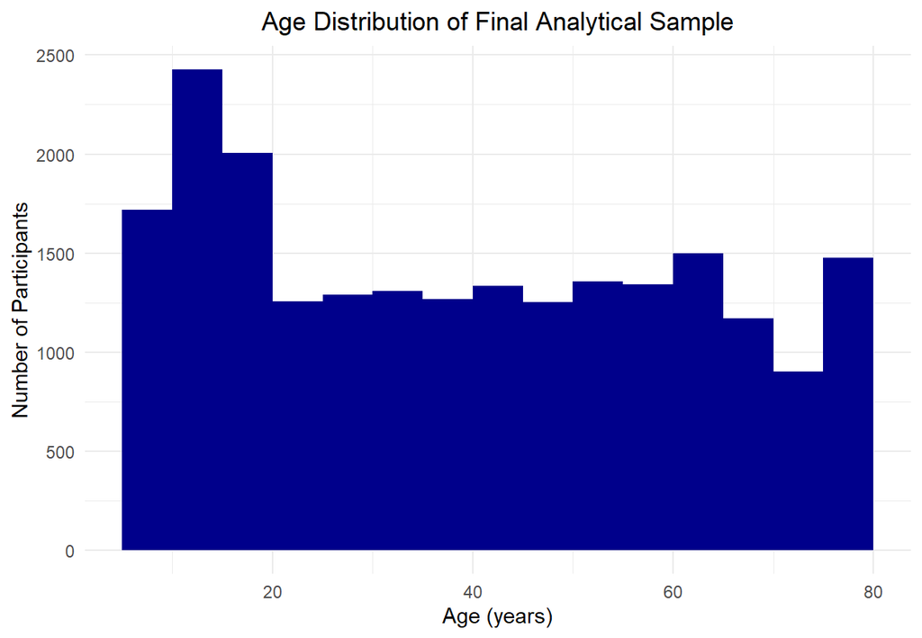

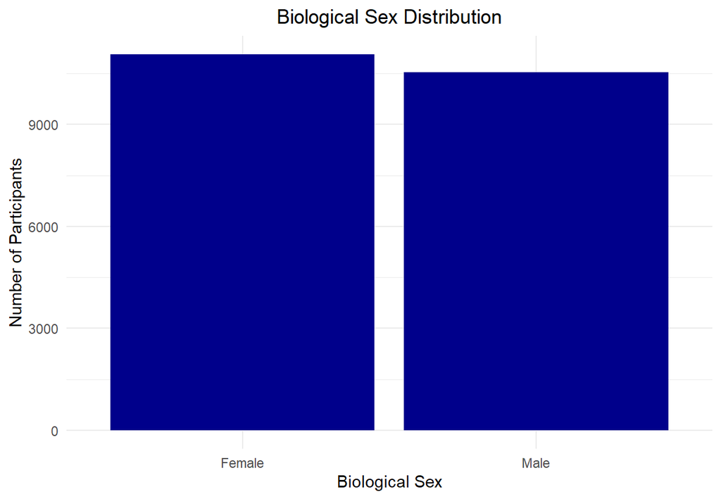

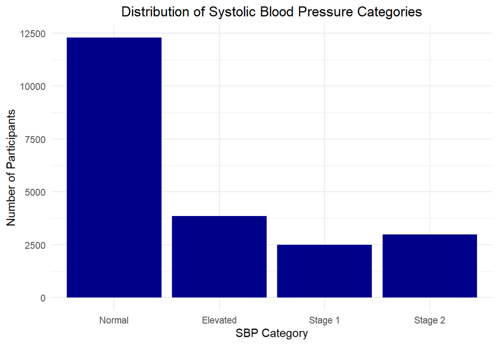

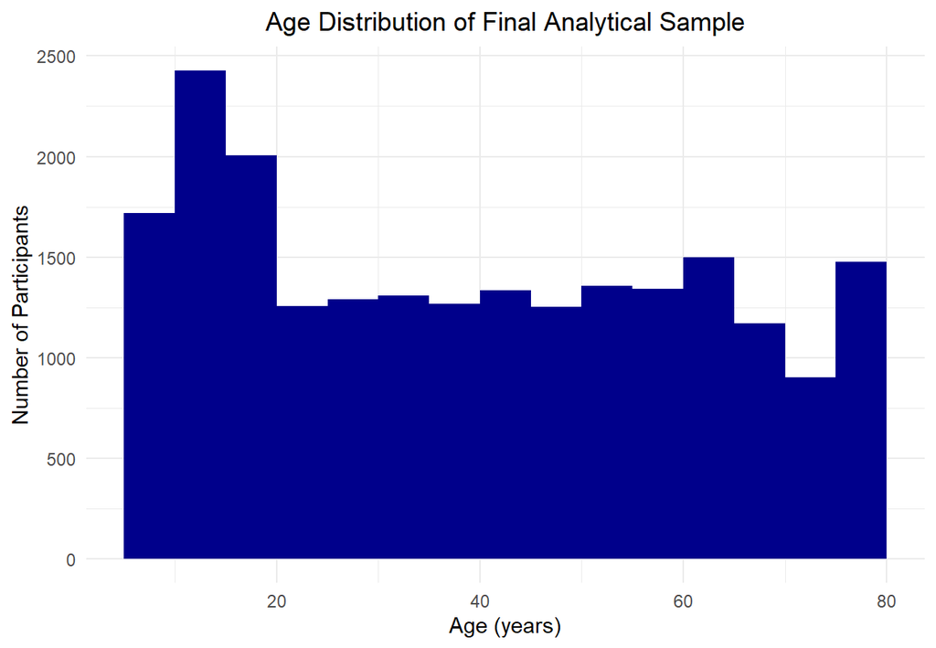

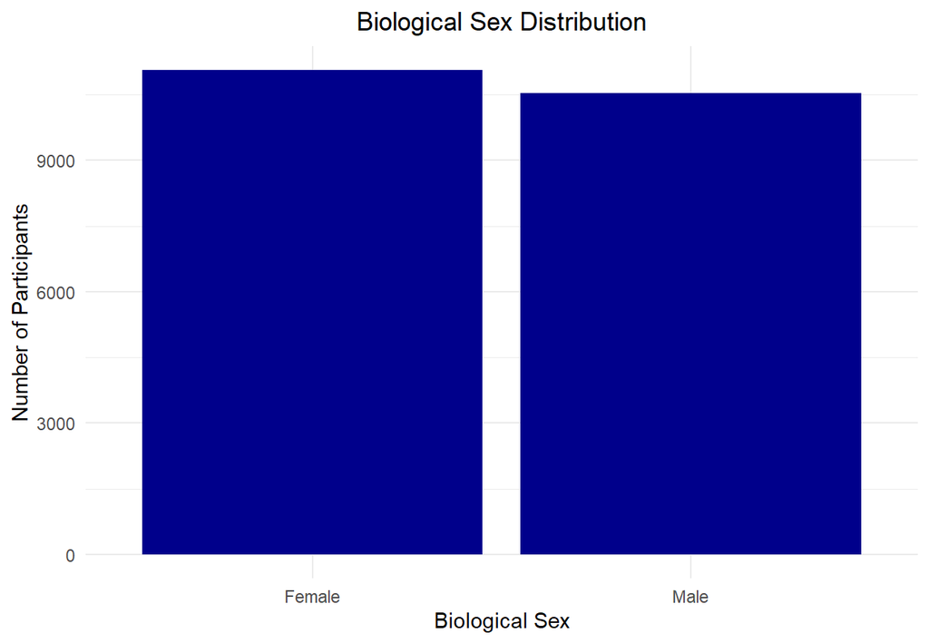

```r
# Compare Exercise 2 and Exercise 4 Age Distributions
# Reuse the age plot created in Exercise 2
plot_age_final <- ggplot(final_sample, aes(x = age)) +
  geom_histogram(
    binwidth = 5,
    boundary = 0,
    fill = "darkblue"
  ) +
  labs(
    title = "Age Distribution - Final Sample",
    x = "Age (years)",
    y = "Number of Participants"
  ) +
  theme_minimal()

# Display the Exercise 2 and Exercise 4 plots together
ggarrange(
  plot_age,
  plot_age_final,
  ncol = 2
)

# Create Blood Pressure Categories
final_sample <- final_sample |>
  mutate(
    sbp_category = case_when(
      avg_sbp < 120 ~ "Normal",
      avg_sbp >= 120 & avg_sbp < 130 ~ "Elevated",
      avg_sbp >= 130 & avg_sbp < 140 ~ "Stage 1",
      avg_sbp >= 140 ~ "Stage 2"
    ),
    sbp_category = factor(
      sbp_category,
      levels = c(
        "Normal",
        "Elevated",
        "Stage 1",
        "Stage 2"
      )
    )
  )

# Create Age Groups
final_sample <- final_sample |>
  mutate(
    age_group = case_when(
      age >= 18 & age <= 29 ~ "18–29",
      age >= 30 & age <= 49 ~ "30–49",
      age >= 50 & age <= 69 ~ "50–69",
      age >= 70 ~ "70+"
    ),
    age_group = factor(
      age_group,
      levels = c(
        "18–29",
        "30–49",
        "50–69",
        "70+"
      )
    )
  )

# Plot Age Distribution in Final Sample
plot_age_final <- ggplot(
  final_sample,
  aes(x = age)
) +
  geom_histogram(
    binwidth = 5,
    boundary = 0,
    fill = "darkblue"
  ) +
  labs(
    title = "Age Distribution of Final Analytical Sample",
    x = "Age (years)",
    y = "Number of Participants"
  ) +
  theme_minimal() +
  theme(
    plot.title = element_text(hjust = 0.5)
  )

plot_age_final
# Plot Biological Sex Distribution

plot_gender_final <- ggplot(
  final_sample,
  aes(x = gender)
) +
  geom_bar(
    fill = "darkblue"
  ) +
  labs(
    title = "Biological Sex Distribution",
    x = "Biological Sex",
    y = "Number of Participants"
  ) +
  theme_minimal() +
  theme(
    plot.title = element_text(hjust = 0.5)
  )

plot_gender_final


# Plot SBP Category Distribution
plot_sbp <- ggplot(
  final_sample,
  aes(x = sbp_category)
) +
  geom_bar(
    fill = "darkblue"
  ) +
  labs(
    title = "Distribution of Systolic Blood Pressure Categories",
    x = "SBP Category",
    y = "Number of Participants"
  ) +
  theme_minimal() +
  theme(
    plot.title = element_text(hjust = 0.5)
  )

plot_sbp


# Final Visualization:
# SBP Category by Age Group and Biological Sex
plot_final <- ggplot(
  final_sample,
  aes(
    x = age_group,
    fill = sbp_category
  )
) +
  geom_bar(
    position = "fill"
  ) +
  facet_wrap(~ gender) +
  labs(
    title = "Distribution of Systolic Blood Pressure Categories by Age and Biological Sex",
    subtitle = "Proportion of participants within each age group",
    x = "Age Group",
    y = "Proportion",
    fill = "SBP Category"
  ) +
  theme_linedraw() +
  theme(
    plot.title = element_text(hjust = 0.5),
    plot.subtitle = element_text(hjust = 0.5)
  )

# Display in the PDF
plot_age_final
plot_gender_final

sample_sizes <- tibble(
  initial_sample = initial_n,
  final_sample = final_n,
  excluded = dropped_n
)
```

[output not shown]

## Descriptive Summary

29,400 → 21,604 → 7,796 excluded